# Assessment_Cleo_Schwarz - Does smoking influence insurance charges?

- Show All Code
- Hide All Code
- View Source

Author

Cleo Schwarz

Published

June 11, 2023

# **Introduction**

Smoking as well as a high BMI are both well known risk factors for many diseases, especially cardiovascular diseases. An increased risk of cardiovascular disease can lead to higher incidence of illness and therefore increased individual medical costs. The aim of this study was to investigate whether smoking has an impact on the individual insurance charges considering insured US citizen.

# **Data**

## Import and transform data

```r
dat <- read_csv(here("data/raw/insurance_with_date.csv"))
str(dat)

insurance <- dat |>
  select(X, age, sex, bmi, smoker, charges) |>
  mutate(sex = factor(sex, levels=c("male", "female"), labels=c("m","f")),
         smoker = factor(smoker))
```

## Descriptive statistics

This table shows the mean, median, SD (standard deviation), smallest and largest values of the factors charges, age and BMI sorted by the smoking status.

```r
summarysmoke <- insurance |>
  tbl_summary(
    by = smoker,
    type = all_continuous() ~ "continuous2",
    include =c("charges","bmi", "age"),
    statistic = all_continuous() ~ c("{mean} ({sd})",
                                  "{median} ({p25}, {p75})",
                                  "{min}, {max}")
  )
summarysmoke
```

| **Characteristic** | **no**, N = 1,064 | **yes**, N = 274 |
| --- | --- | --- |
| charges |  |  |
| Mean (SD) | 10,129 (6,090) | 33,654 (11,615) |
| Median (IQR) | 9,240 (5,502, 13,003) | 35,699 (22,326, 42,788) |
| Range | 1,382, 38,455 | 14,417, 66,740 |
| bmi |  |  |
| Mean (SD) | 30.7 (6.0) | 30.7 (6.3) |
| Median (IQR) | 30.4 (26.3, 34.4) | 30.4 (26.1, 35.2) |
| Range | 16.0, 53.1 | 17.2, 52.6 |
| age |  |  |
| Mean (SD) | 39 (14) | 39 (14) |
| Median (IQR) | 40 (27, 52) | 38 (27, 49) |
| Range | 18, 64 | 18, 64 |

### Box-Plot

The following box-plot shows the distribution of charges paid by smokers vs. non smokers.

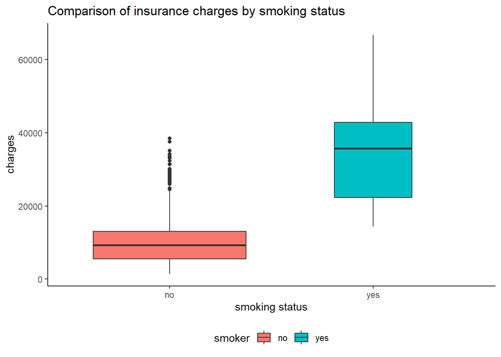

```r
ggplot(insurance , aes(x = smoker, y = charges, fill = smoker )) +
  geom_boxplot(varwidth = TRUE) +
  ggtitle(label = "Comparison of insurance charges by smoking status") +
  xlab(label = "smoking status") +
  ylab(label = "charges")+
  theme_classic() + theme(legend.position="bottom")
```

## Test for normality

To test if the distribution of the dataset “charges” is normal or not, a QQ-Plot and a histogram were performed. For an additional check for normality, a [shapiro test](https://en.wikipedia.org/wiki/Shapiro%E2%80%93Wilk_test) was also done. The analyses were conducted first with the normal data and secondly with the logarithmic data.

### QQ-Plot

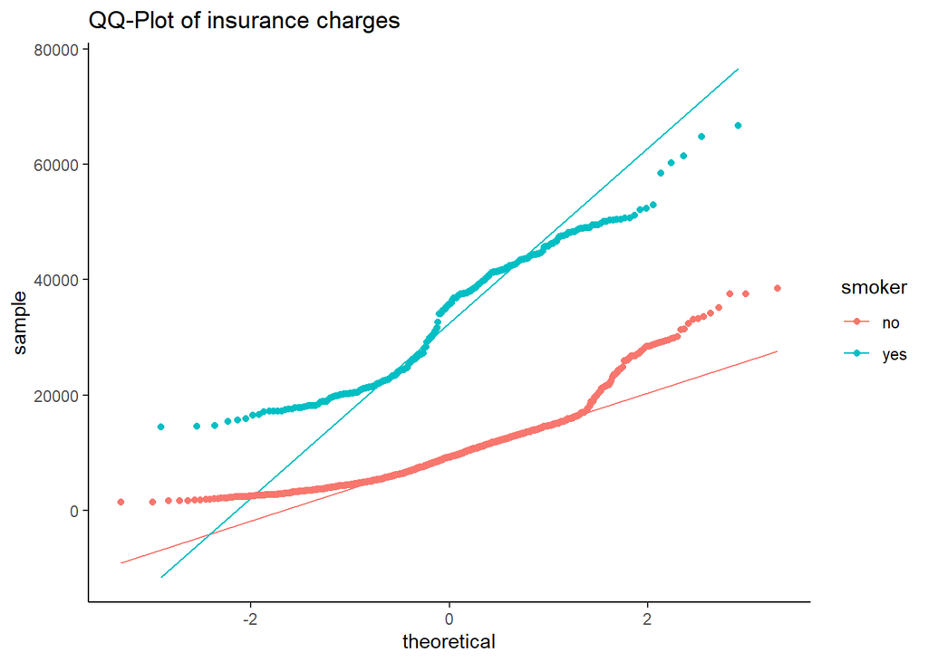

```r
insurance %>%
  ggplot(aes(sample = charges, fill = smoker, colour = smoker)) +
  geom_qq_line(distribution = stats::qnorm) +
  geom_qq(distribution = stats::qnorm) +
  ggtitle(label = "QQ-Plot of insurance charges") +
  xlab("theoretical") +
  ylab("sample") +
  theme_classic()
```

```r
insurance |>
  group_by(smoker) |>
  shapiro_test(charges)
```

| smoker | variable | statistic | p |
| --- | --- | --- | --- |
| no | charges | 0.8877355 | 4.269487e-27 |
| yes | charges | 0.9443327 | 1.119289e-08 |

### Histogram

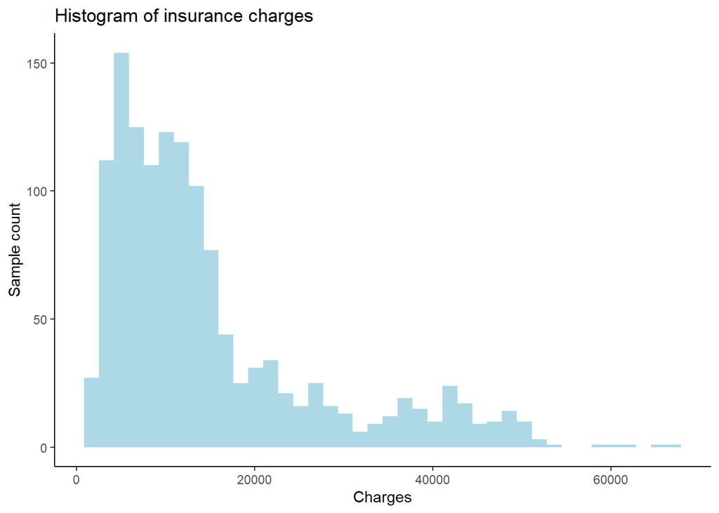

```r
ggplot(insurance, aes(x=charges)) +
  geom_histogram(bins=40, fill = "lightblue") +
  ggtitle(label = "Histogram of insurance charges") +
  xlab("Charges") +
  ylab("Sample count") +
  theme_classic()
```

### Interpretation

The QQ-Plot as well as the histogram show that the data is not in normal distribution.  
The results of the shapiro test also underlined non normal distribution (Null hypothesis of normal distribution was rejected because of a p-value < alpha).

But according to the [Central Limit Theorem](https://en.wikipedia.org/wiki/Central_limit_theorem), given a sample size above 30, the sampling distribution of the standardized sample mean approach the standard normal distribution even if the original variables themselves are not normally distributed.

### QQ-Plot - logarithmic values

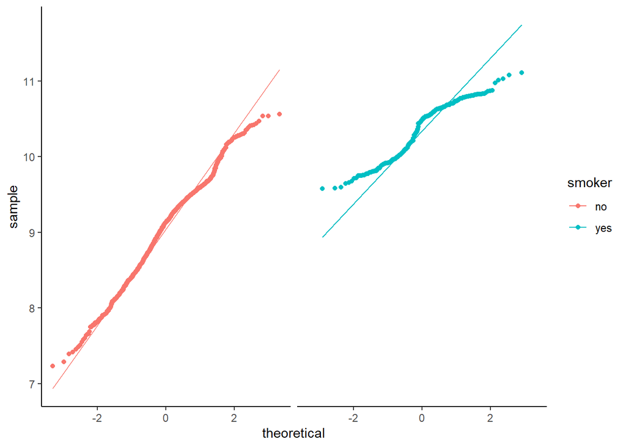

```r
insurance$charges_log <- log(insurance$charges)

insurance %>%
  ggplot(aes(sample = charges_log, fill = smoker, colour = smoker)) +
  geom_qq_line(distribution = stats::qnorm) +
  geom_qq(distribution = stats::qnorm) +
  xlab("theoretical") +
  ylab("sample") +
  theme_classic() +
  facet_wrap("smoker") +
  theme(strip.text = element_blank())
```

```r
insurance |>
  group_by(smoker) |>
  shapiro_test(charges_log)
```

| smoker | variable | statistic | p |
| --- | --- | --- | --- |
| no | charges_log | 0.9896244 | 7.775043e-07 |
| yes | charges_log | 0.9353390 | 1.403670e-09 |

### Histogram - logarithmic values

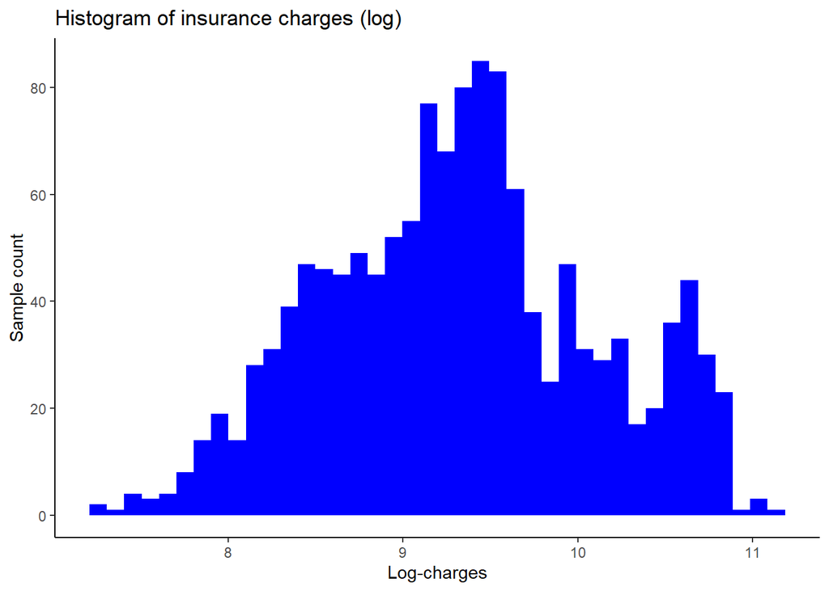

```r
ggplot(insurance, aes(x=charges_log)) +
  geom_histogram(bins=40, fill = "blue") +
  ggtitle(label = "Histogram of insurance charges (log)") +
  xlab("Log-charges") +
  ylab("Sample count") +
  theme_classic()
```

### Interpretation

By taking the logarithmic value, a conversion into normal distribution was not possible.

## Comparison of the means of charges for smokers vs. non smokers

Two statistical test were performed in order to compare the means of two populations (insurance charges for smokers vs. non smokers).

Assuming normal distribution of the mean of charges, a student’s t-test was possible.

```r
insurance |>
  wilcox_test(charges ~ smoker)
```

|  | .y. | group1 | group2 | n1 | n2 | statistic | p |
| --- | --- | --- | --- | --- | --- | --- | --- |
| 1 | charges | no | yes | 1064 | 274 | 7715 | 1.99e-129 |

```r
insurance |>
  t_test(charges ~ smoker) |>
  rename(non_smoker = group1, smoker = group2)
```

|  | .y. | non_smoker | smoker | n1 | n2 | statistic | df | p |
| --- | --- | --- | --- | --- | --- | --- | --- | --- |
| 1 | charges | no | yes | 1064 | 274 | -32.40051 | 312.6169 | 6.07e-102 |

### Interpretation

The low p-value indicates that the means of insurance charges of smokers vs. non-smokers were of statistical significant difference.

# Conclusion

The analysis showed that there is a statistical significant association between higher insurance charges and smoking in US citizen. Nevertheless, this is not a correlation and there can be other factors than smoking influencing the higher individual charges. Since a high BMI is also seen as a risk factor for disease, it would be of interest to investigate the impact of obesity on insurance charges. Further studies are needed to asses a correlation between smoking and insurance charges as well as the impact of other risk factors on medical costs.